# Create a Kapacitor Alert

Chronograf provides a user interface for Kapacitor, InfluxData’s processing framework for creating alerts, running ETL jobs, and detecting anomalies in your data.

This guide offers step-by-step instructions for creating a Kapacitor alert in Chronograf. By the end of this guide, you’ll have an alert rule that sends a message to an existing [Slack](https://slack.com/) channel whenever your idle CPU usage crosses the 80% threshold.

## Requirements

This guide assumes that you’ve already downloaded and installed each component of the TICK stack (Telegraf, InfluxDB, Chronograf, and Kapacitor). To follow along, the Telegraf instance must be configured to collect data with the [system statistics](https://github.com/influxdata/telegraf/tree/master/plugins/inputs/system) input plugin and write data to your InfluxDB instance. The steps below also assume that you’ve already configured your Kapacitor instance in Chronograf. The Getting Started guide offers step-by-step instructions for each of those requirements.

The steps below also assume that you have a working Slack instance and that you’ve configured it as an event handler in Chronograf. See the Configure Kapacitor Event Handlers guide for detailed configuration instructions.

## Configure a Kapacitor alert rule

Before you start, navigate to the Rule Configuration page by visiting the Alert Rules page and clicking on the `Create Rule` button in the top right corner.

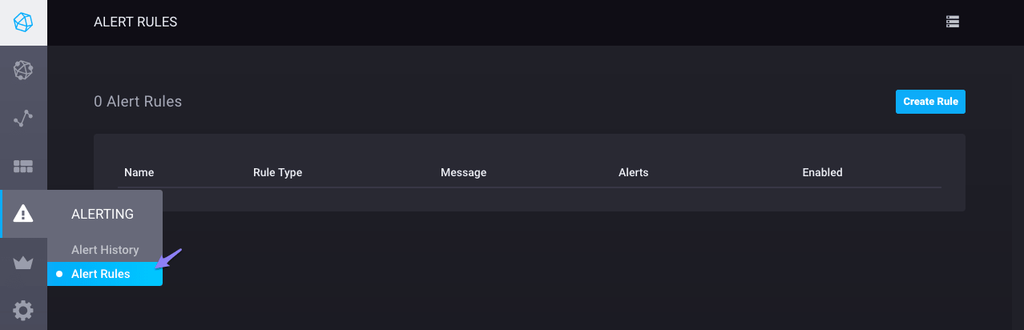

The Rule Configuration page is where you create and edit your Kapacitor alert rules. Steps one through six walk you through each section of the Rule Configuration page:

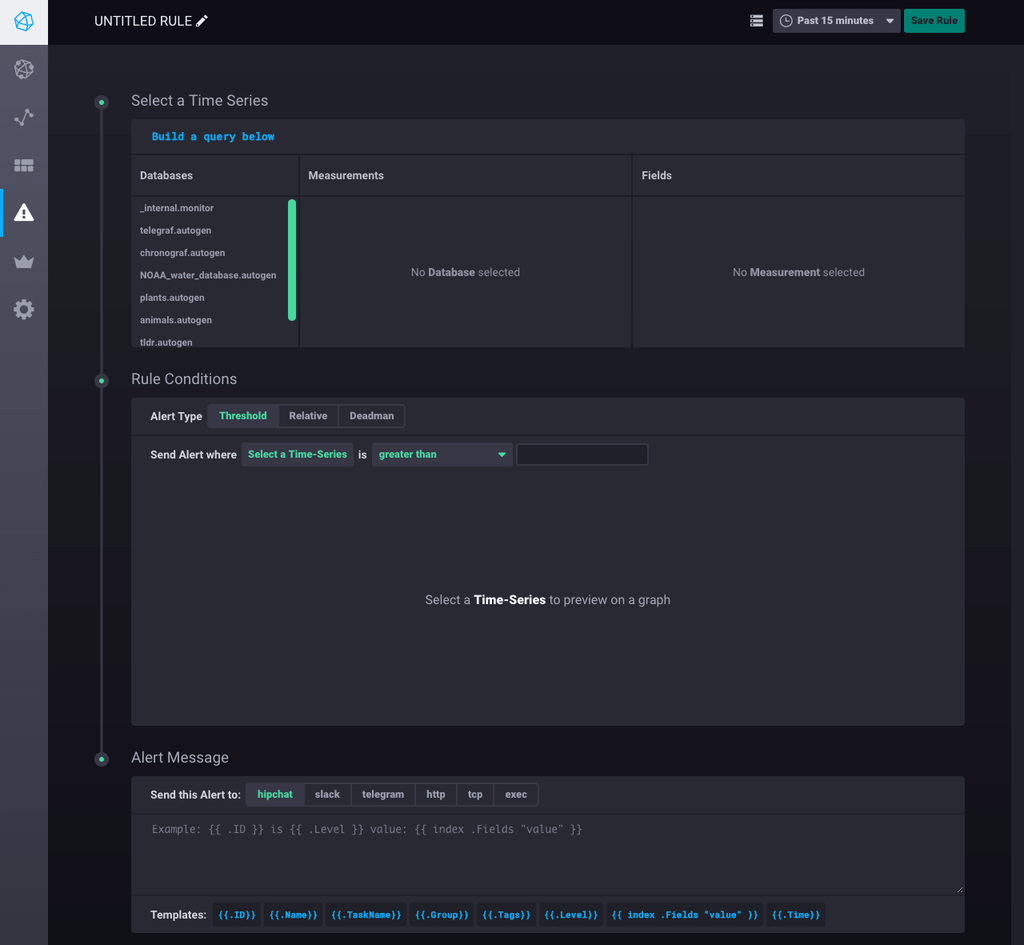

### Step 1: Name the rule

Name the alert rule by clicking on `Untitled Rule` in the top left corner. You can call your rule anything you want and you can always change it later. Here, we call it `Idle CPU Usage`:

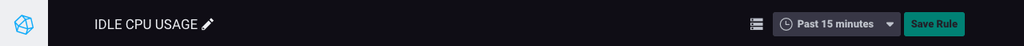

### Step 2: Select the time series

Next, choose the data that you want the alert rule to work with. Navigate through the `Databases`, `Measurements`, `Fields`, and `Tags` tabs to select the relevant data.

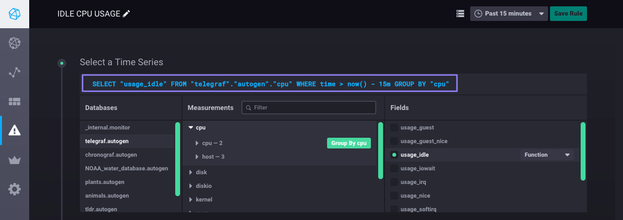

### Step 3: Select the alert type

Choose from three alert types in the `Rule Conditions` section of the Rule Configuration page. The three alert types are:

- Threshold - alert if the data cross a boundary
- Relative - alert if the data change relative to the data in a different time range
- Deadman - alert if InfluxDB receives no relevant data for the specified time duration

Here, we select the `Threshold` alert type.

### Step 4: Define the rule condition

Next, define the threshold condition:

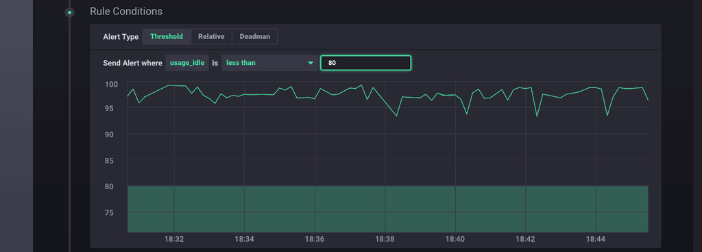

- `usage_idle`: The field key specified in the `Select a Time Series` section.
- `Less than`: The condition type. Chronograf supports several condition types.
- `80`: The threshold number. The system sends an alert when the `usage_idle` data cross that boundary.

The graph shows a preview of the relevant data and the threshold number. By default, the graph shows data within the past 15 minutes. The time range selector in the top right corner adjusts the graph’s time range. Use this feature when determining a reasonable threshold number based on your data.

> **Note:** We set the threshold number to `80` for demonstration purposes. On our machine, setting the threshold for idle CPU usage to a high number ensures that we’ll be able to see the alert in action. In practice, you’d set the threshold number to better match the patterns in your data and your alert needs.

### Step 5: Select the event handler and configure the alert message

The `Alert Message` section on the Rule Configuration page determines where the system sends the alert (the event handler) and the text that accompanies the alert (the alert message). Chronograf supports several event handlers. Here, we choose to send alerts to Slack, specifically to the existing `#chronocats` channel.

The alert message is the text that accompanies an alert. In this example, the alert message is `Your idle CPU usage is {{.Level}} at {{ index .Fields "value" }}. 😸`. `{{.Level}}` is a template that evaluates to `CRITICAL` when the `usage_idle` data initially dip below 80% and `OK` when the `usage_idle` data first return to 80% or above. The `{{ index .Fields "value" }}` template prints the relevant field value that triggered the alert.

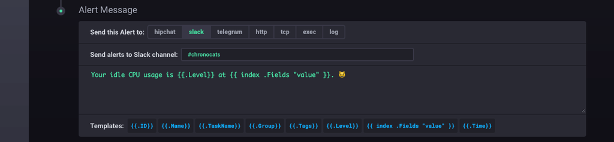

> **Note:** There’s no need to include a Slack channel in the `Alert Message` section if you specified a default channel in the initial Slack configuration. If you did not include a default channel in the initial configuration or if you’d like to send alerts to a non-default channel, specify an alternative Slack channel in this section.

### Step 6: Save the alert rule

You’re all set! Click the `Save Rule` button in the top right corner and navigate to the Kapacitor Rule page to see your rule. Notice that you can easily enable and disable the rule by toggling the checkbox in the `Enabled` column.

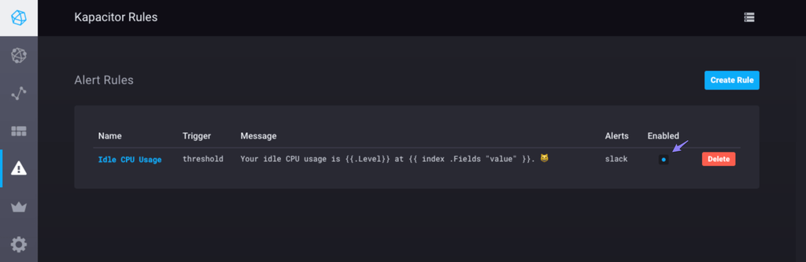

Next, move on to the section below to experience your alert rule in action.

## View the alert in practice

### Step 1: Create some load on your system

The purpose of this step is to generate enough load on your system to trigger an alert. More specifically, your idle CPU usage must dip below `80%`. On the machine that’s running Telegraf, enter the following command in the terminal to start some `while` loops:

```
while true; do i=0; done
```

Let it run for a couple seconds or minutes before terminating it. On most systems, kill the script by selecting the `Ctrl-c` keys.

### Step 2: Visit Slack

Next, visit the Slack channel that you specified in the previous section. In this example, it’s the `#chronocats` channel.

- The first alert message indicates that your idle CPU usage was `CRITICAL`, that is, it dipped below `80%`. The specific field value that triggered the alert is `69.59999999998138`.
- The second alert message indicates that your idle CPU usage returned to an `OK` level, that is, it returned to `80%` or above. The specific field value that triggered the alert is `99.0981963931105`.

[figure not shown]

That’s it! You’ve successfully used Chronograf to configure a Kapacitor alert rule to monitor your idle CPU usage.

© 2015 InfluxData, Inc.  
Licensed under the MIT license.  
https://docs.influxdata.com/chronograf/v1.3/guides/create-a-kapacitor-alert/